# 01 - Exploratory Data Analysis (EDA) for HR Attrition

## Objective

The primary goal of this notebook is to perform a comprehensive Exploratory Data Analysis (EDA) on the HR dataset. This involves:

- Understanding the dataset's structure, distributions, and relationships.
- Identifying missing values, outliers, and potential data quality issues.
- Generating key performance indicators (KPIs) and visualizations relevant to employee attrition.
- Deriving initial insights that will inform subsequent data cleaning, feature engineering, and model development.

## 1. Setup and Data Loading

```python
import pandas as pd
import numpy as np
import matplotlib.pyplot as plt
import seaborn as sns
import plotly.express as px
from pathlib import Path

# Set display options for better readability
pd.set_option('display.max_columns', None)
pd.set_option('display.width', 1000)

# Set style for seaborn plots
sns.set_style("whitegrid")

# Define paths (assuming notebook is in 'notebooks/' and data in 'data/processed/')
project_root = Path(__file__).parent.parent if '__file__' in locals() else Path.cwd().parent
processed_data_path = project_root / 'data' / 'processed' / 'hr_dataset.csv'

print(f"Loading data from: {processed_data_path}")
try:
    df = pd.read_csv(processed_data_path)
    print("Data loaded successfully.")
except FileNotFoundError:
    print(f"Error: The file {processed_data_path} was not found.")
    print("Please ensure 'src/data/load_data.py' has been run to create the processed CSV.")
    df = pd.DataFrame() # Create an empty DataFrame to prevent errors further down
except Exception as e:
    print(f"An error occurred while loading the data: {e}")
    df = pd.DataFrame()
```

```
Loading data from: c:\Users\pc\Documents\GitHub Apps\hr-analytics-dashboard\data\processed\hr_dataset.csv
Data loaded successfully.
```

## 2. Initial Data Inspection

```python
if not df.empty:
    print("### Dataset Head ###")
    display(df.head())

    print("\n### Dataset Info ###")
    df.info()

    print("\n### Dataset Shape ###")
    print(f"Rows: {df.shape[0]}, Columns: {df.shape[1]}")
```

```
### Dataset Head ###
```

|  | EmployeeID | Name | Department | Gender | JobRole | Education | Age | Salary | Bonus | Attrition | TotalCompensation |
| --- | --- | --- | --- | --- | --- | --- | --- | --- | --- | --- | --- |
| 0 | 1001 | Emp_1 | Sales | Male | Manager | High School | 39 | 39239.0 | 6909 | No | 46148.0 |
| 1 | 1002 | Emp_2 | Marketing | Male | Consultant | Masters | 53 | 30416.0 | 17150 | No | 47566.0 |
| 2 | 1003 | Emp_3 | IT | Female | Executive | High School | 24 | 23412.0 | 28602 | No | 52014.0 |
| 3 | 1004 | Emp_4 | Marketing | Female | Engineer | Masters | 23 | 101976.0 | 5080 | No | 107056.0 |
| 4 | 1005 | Emp_5 | Marketing | Male | Executive | PhD | 54 | 44406.0 | 7083 | No | 51489.0 |

[output not shown]

## 3. Data Profiling: Summary Statistics & Missing Values

```
### Summary Statistics for Numerical Features ###
```

|  | EmployeeID | Age | Salary | Bonus | TotalCompensation |
| --- | --- | --- | --- | --- | --- |
| count | 2000.000000 | 2000.000000 | 1960.000000 | 2000.000000 | 1960.000000 |
| mean | 2000.500000 | 40.469000 | 69234.925510 | 17676.264000 | 86881.781633 |
| std | 577.494589 | 10.900112 | 29729.536674 | 7231.226538 | 30420.866873 |
| min | 1001.000000 | 22.000000 | -30000.000000 | 5011.000000 | -6323.000000 |
| 25% | 1500.750000 | 31.000000 | 43207.000000 | 11388.500000 | 60201.750000 |
| 50% | 2000.500000 | 40.000000 | 69137.500000 | 17882.500000 | 86939.000000 |
| 75% | 2500.250000 | 50.000000 | 95121.000000 | 23732.750000 | 113048.250000 |
| max | 3000.000000 | 59.000000 | 119981.000000 | 29993.000000 | 149027.000000 |

```
### Summary Statistics for Categorical Features ###
```

|  | Name | Department | Gender | JobRole | Education | Attrition |
| --- | --- | --- | --- | --- | --- | --- |
| count | 2000 | 1961 | 1961 | 2000 | 2000 | 1960 |
| unique | 2000 | 12 | 8 | 5 | 4 | 2 |
| top | Emp_1 | HR | Female | Analyst | Masters | No |
| freq | 1 | 343 | 1000 | 416 | 521 | 1570 |

```
### Missing Values Analysis ###
```

|  | Missing Count | Missing Percentage |
| --- | --- | --- |
| Salary | 40 | 2.00 |
| Attrition | 40 | 2.00 |
| TotalCompensation | 40 | 2.00 |
| Department | 39 | 1.95 |
| Gender | 39 | 1.95 |

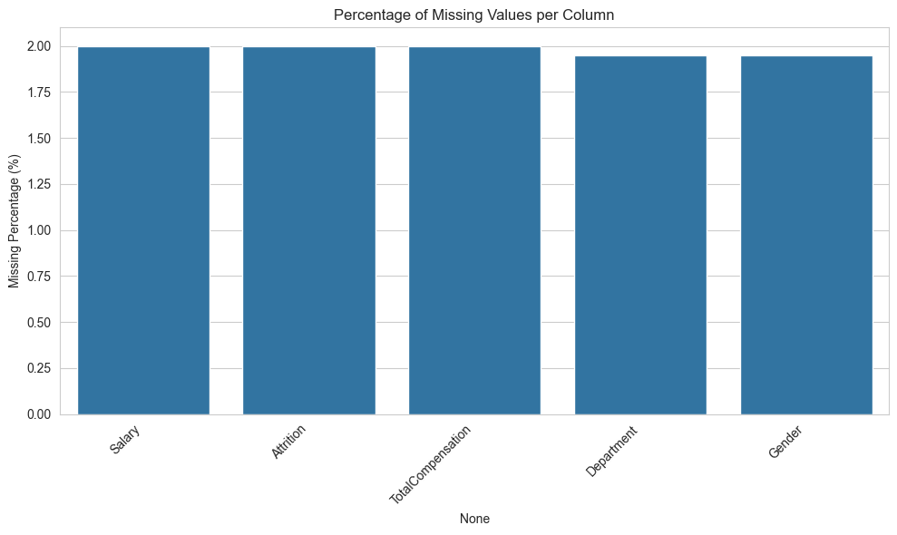

```python
if not df.empty:
    print("### Summary Statistics for Numerical Features ###")
    display(df.describe())

    print("\n### Summary Statistics for Categorical Features ###")
    display(df.describe(include='object'))

    print("\n### Missing Values Analysis ###")
    missing_values = df.isnull().sum()
    missing_percentage = (missing_values / len(df)) * 100
    missing_df = pd.DataFrame({
        'Missing Count': missing_values,
        'Missing Percentage': missing_percentage
    }).sort_values(by='Missing Percentage', ascending=False)

    # Filter to show only columns with missing values
    missing_df = missing_df[missing_df['Missing Count'] > 0]

    if not missing_df.empty:
        display(missing_df)

        # Visualize missing values
        plt.figure(figsize=(10, 6))
        sns.barplot(x=missing_df.index, y='Missing Percentage', data=missing_df)
        plt.title('Percentage of Missing Values per Column')
        plt.ylabel('Missing Percentage (%)')
        plt.xticks(rotation=45, ha='right')
        plt.tight_layout()
        plt.show()
    else:
        print("No missing values found in the dataset.")
```

## 4. Data Profiling: Duplicates & Unique Values

```python
if not df.empty:
    print("### Duplicate Rows Analysis ###")
    num_duplicates = df.duplicated().sum()
    if num_duplicates > 0:
        print(f"Found {num_duplicates} duplicate rows.")
        # Optional: display some duplicate rows
        # display(df[df.duplicated(keep=False)].sort_values(by=list(df.columns)).head())
    else:
        print("No duplicate rows found.")

    print("\n### Unique Values per Column ###")
    unique_counts = df.nunique().sort_values(ascending=False)
    display(unique_counts.to_frame(name='Unique Count'))

    # Identify columns with very few unique values (potential categorical or identifier columns)
    print("\n### Columns with few unique values (potential categorical) ###")
    low_cardinality_cols = unique_counts[unique_counts < 50].index.tolist() # Threshold can be adjusted
    for col in low_cardinality_cols:
        if df[col].dtype == 'object' or df[col].nunique() < 10: # Also show for clearly categorical numerical
            print(f"- {col}: {df[col].unique()}")
```

```
### Duplicate Rows Analysis ###
No duplicate rows found.

### Unique Values per Column ###
```

|  | Unique Count |
| --- | --- |
| EmployeeID | 2000 |
| Name | 2000 |
| TotalCompensation | 1948 |
| Salary | 1932 |
| Bonus | 1909 |
| Age | 38 |
| Department | 12 |
| Gender | 8 |
| JobRole | 5 |
| Education | 4 |
| Attrition | 2 |

```
### Columns with few unique values (potential categorical) ###
- Department: ['Sales' 'Marketing' 'IT' 'Finance' 'Operations' 'HR' nan 'I.T' 'HRR'
 'Finanace' 'hr' 'Slaes' 'Markting']
- Gender: ['Male' 'Female' nan 'MALE' 'Fem' 'FEMALE' 'M' 'malee' 'femal']
- JobRole: ['Manager' 'Consultant' 'Executive' 'Engineer' 'Analyst']
- Education: ['High School' 'Masters' 'PhD' 'Bachelors']
- Attrition: ['No' 'Yes' nan]
```

## 5. Univariate Analysis (Individual Feature Distributions)

### 5.1 Numerical Features

```
### Distribution of Key Numerical Features (Histograms & KDE) ###
```

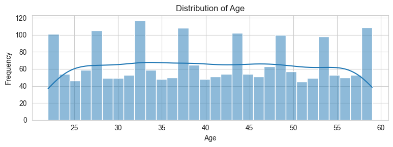

```
### Boxplots for Numerical Features (Outlier Detection) ###
```

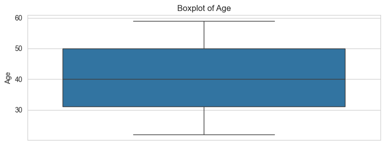

```python
if not df.empty:
    numerical_cols = df.select_dtypes(include=np.number).columns.tolist()
    # Exclude IDs or purely categorical numerical columns if they exist (e.g., 'EmployeeID')
    # For now, let's assume 'Age', 'MonthlyIncome', 'DistanceFromHome' are good candidates
    # You might need to adjust this based on your specific dataset columns
    relevant_numerical = ['Age', 'MonthlyIncome', 'DistanceFromHome', 'YearsAtCompany', 'TotalWorkingYears', 'NumCompaniesWorked'] # Add more as per your dataset
    relevant_numerical = [col for col in relevant_numerical if col in numerical_cols]

    print("### Distribution of Key Numerical Features (Histograms & KDE) ###")
    plt.figure(figsize=(15, len(relevant_numerical) * 3))
    for i, col in enumerate(relevant_numerical, 1):
        plt.subplot(len(relevant_numerical) // 2 + (len(relevant_numerical) % 2), 2, i)
        sns.histplot(df[col], kde=True, bins=30)
        plt.title(f'Distribution of {col}')
        plt.xlabel(col)
        plt.ylabel('Frequency')
    plt.tight_layout()
    plt.show()

    print("\n### Boxplots for Numerical Features (Outlier Detection) ###")
    plt.figure(figsize=(15, len(relevant_numerical) * 3))
    for i, col in enumerate(relevant_numerical, 1):
        plt.subplot(len(relevant_numerical) // 2 + (len(relevant_numerical) % 2), 2, i)
        sns.boxplot(y=df[col])
        plt.title(f'Boxplot of {col}')
        plt.ylabel(col)
    plt.tight_layout()
    plt.show()
```

### 5.2 Categorical Features

```
### Distribution of Categorical Features (Count Plots) ###
```

[figure not shown]

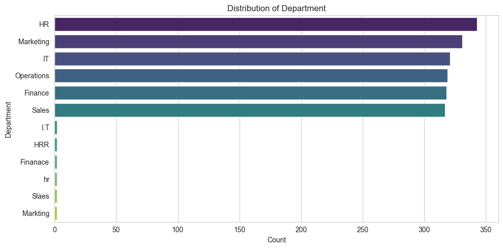

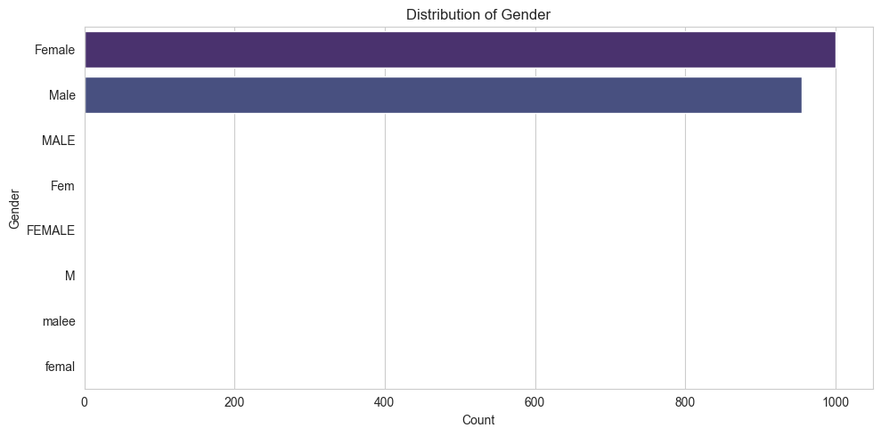

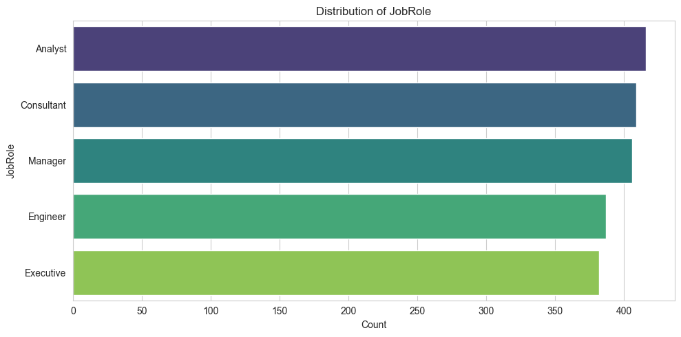

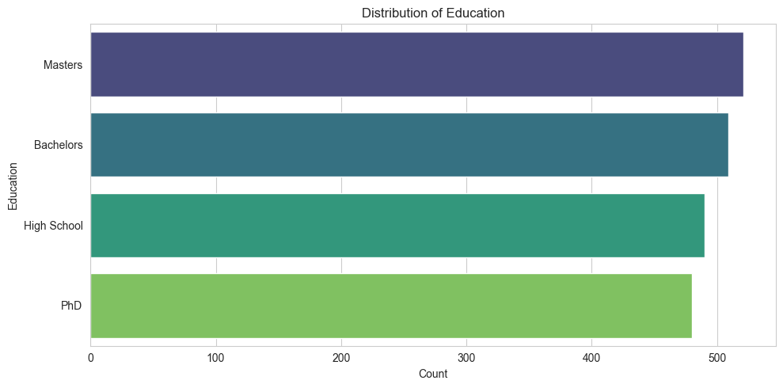

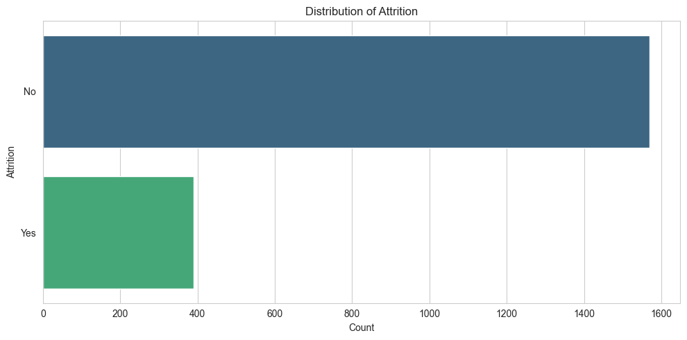

```python
if not df.empty:
    categorical_cols = df.select_dtypes(include='object').columns.tolist()
    # Add any numerical columns that are actually categorical (e.g., 'Education', 'JobLevel' if they are codes)
    # For this example, let's also include 'Education', 'EnvironmentSatisfaction', etc., assuming they are numerical but represent categories
    potential_categorical_numerical = ['Education', 'EnvironmentSatisfaction', 'JobInvolvement',
                                       'JobLevel', 'JobSatisfaction', 'PerformanceRating',
                                       'RelationshipSatisfaction', 'StockOptionLevel', 'WorkLifeBalance']
    categorical_cols.extend([col for col in potential_categorical_numerical if col in df.columns and col not in categorical_cols])

    print("### Distribution of Categorical Features (Count Plots) ###")
    for col in categorical_cols:
        plt.figure(figsize=(10, 5))
        sns.countplot(y=df[col], order=df[col].value_counts().index, palette='viridis')
        plt.title(f'Distribution of {col}')
        plt.xlabel('Count')
        plt.ylabel(col)
        plt.tight_layout()
        plt.show()
```

## 6. Bivariate/Multivariate Analysis (Relationships & KPIs)

### 6.1 Attrition Rate Analysis (KPIs)

```
### Overall Attrition Rate: 19.90% ###

Attrition Rate by Department:
```

| Department | Attrition Rate (%) |
| --- | --- |
| Finanace | 50.00% |
| I.T | 50.00% |
| Sales | 21.86% |
| Marketing | 21.47% |
| HR | 20.54% |
| IT | 19.75% |
| Operations | 18.67% |
| Finance | 17.36% |
| HRR | 0.00% |
| Markting | 0.00% |
| Slaes | 0.00% |
| hr | 0.00% |

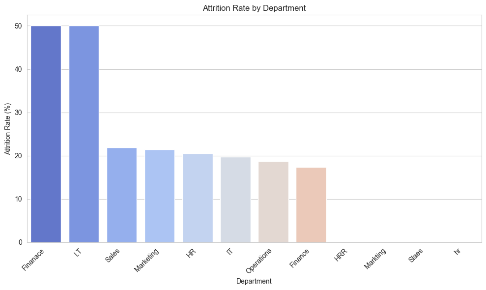

```
Attrition Rate by JobRole:
```

| JobRole | Attrition Rate (%) |
| --- | --- |
| Consultant | 20.70% |
| Manager | 20.35% |
| Executive | 20.16% |
| Engineer | 19.53% |
| Analyst | 18.77% |

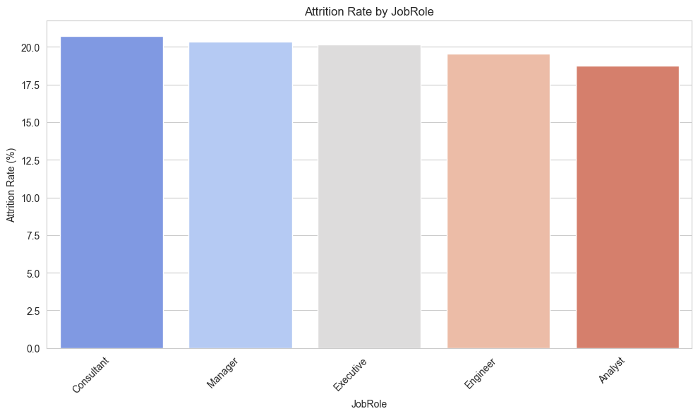

```
Attrition Rate by Gender:
```

| Gender | Attrition Rate (%) |
| --- | --- |
| M | 100.00% |
| malee | 100.00% |
| Male | 20.34% |
| Female | 19.45% |
| FEMALE | 0.00% |
| Fem | 0.00% |
| MALE | 0.00% |
| femal | 0.00% |

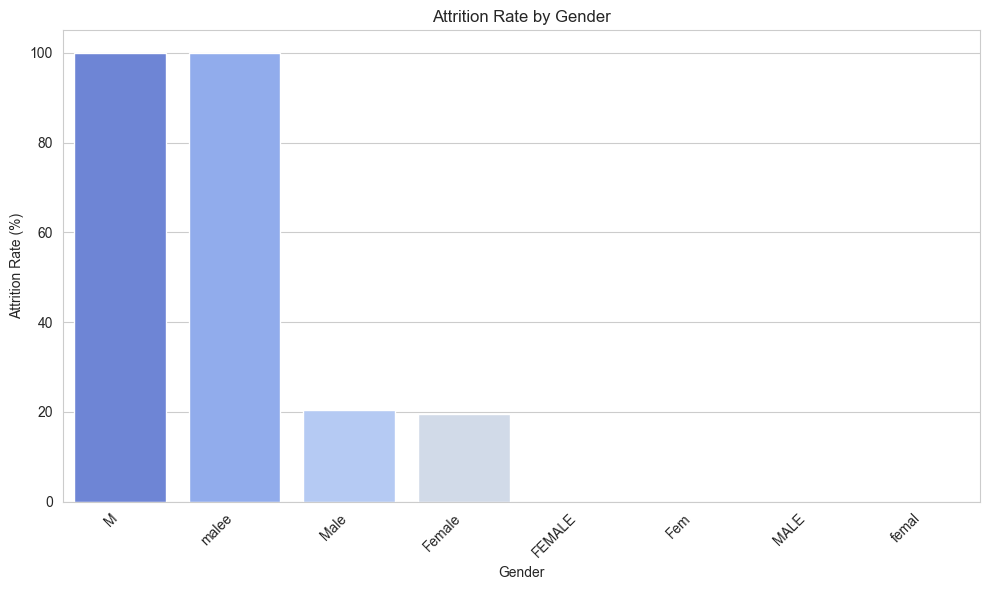

```python
if not df.empty:
    # Ensure 'Attrition' is a binary column (0/1 or 'Yes'/'No')
    # If 'Attrition' is string 'Yes'/'No', convert it to numerical 1/0 for easier calculation
    df['Attrition_Numeric'] = df['Attrition'].map({'Yes': 1, 'No': 0}) if 'Attrition' in df.columns and df['Attrition'].dtype == 'object' else df['Attrition']

    if 'Attrition_Numeric' in df.columns:
        overall_attrition_rate = df['Attrition_Numeric'].mean() * 100
        print(f"### Overall Attrition Rate: {overall_attrition_rate:.2f}% ###\n")

        attrition_by_features = ['Department', 'JobRole', 'Gender', 'EducationField', 'MaritalStatus'] # Add more as relevant

        for feature in attrition_by_features:
            if feature in df.columns:
                attrition_rate_by_feature = df.groupby(feature)['Attrition_Numeric'].mean().sort_values(ascending=False)
                print(f"Attrition Rate by {feature}:")
                display(attrition_rate_by_feature.to_frame(name='Attrition Rate (%)').style.format('{:.2%}'))

                plt.figure(figsize=(10, 6))
                sns.barplot(x=attrition_rate_by_feature.index, y=attrition_rate_by_feature.values * 100, palette='coolwarm')
                plt.title(f'Attrition Rate by {feature}')
                plt.ylabel('Attrition Rate (%)')
                plt.xticks(rotation=45, ha='right')
                plt.tight_layout()
                plt.show()
    else:
        print("Attrition column not found or not in expected format for rate calculation.")
```